# Airline Satisfaction

Landon James

March 15th, 2024

## Marketing Problem

##### The marketing problem addressed in this analysis revolves around helping airlines gain deeper insights into their customers’ preferences and experiences. By understanding these needs and wants more comprehensively, airlines can tailor their services to better meet customer expectations, ultimately enhancing overall satisfaction. Moreover, optimizing marketing strategies based on these insights enables airlines to effectively target their audience segments, improving customer acquisition and retention efforts. Additionally, by identifying areas of strength and weakness in service provision, airlines can strategically allocate resources to enhance the quality of offerings where necessary and streamline expenditures where demand may be lower, leading to more efficient resource management. Overall, the objective is to empower airlines with the knowledge needed to optimize their operations, marketing initiatives, and resource allocation strategies in alignment with customer preferences and market dynamics.

## Dataset

### Importing Libraries Needed for Analysis

```r
library(tidyverse)
library(readxl)
library(broom)
library(lubridate)
library(ggplot2)
library(tidyr)
library(dplyr)
library(corrplot)
library(psych)
library(stats)
library(readr)
library(fastDummies)
```

### Load in Datasets

```r
train <- read_csv('train.csv')
test <- read_csv('test.csv')
```

##### The dataset comprises various factors related to customer experiences in airline travel. It includes demographic information such as gender, age, and customer type, which distinguishes between regular and loyal customers. Additionally, travel details like the type of travel (personal or business), class of service, and flight distance are recorded. The dataset also incorporates ratings for both inflight and preflight services, covering aspects like wifi connectivity, entertainment, seating comfort, and cleanliness, among others. These ratings provide insights into customer satisfaction with the overall travel experience. Notably, delays in departure and arrival times are captured, allowing for an analysis of punctuality issues. The primary focus lies on optimizing airline services and marketing strategies to enhance customer satisfaction and loyalty, thereby improving the overall travel experience and maximizing resource allocation efficiency.

### Data Cleaning

```r
train <- train %>% mutate(satisfaction = ifelse(satisfaction == "satisfied", 1, 0))
train <- train %>% mutate(Class = ifelse(Class == "Business", 1, 0))
train <- train %>% mutate(Gender = ifelse(Gender == "Male", 1, 0))
train <- train %>% mutate(`Type of Travel` = ifelse(`Type of Travel` == "Personal Travel", 1, 0))
train <- train %>% mutate(`Customer Type` = ifelse(`Customer Type` == "Loyal Customer", 1, 0))

test <- test %>% mutate(satisfaction = ifelse(satisfaction == "satisfied", 1, 0))
test <- test %>% mutate(Class = ifelse(Class == "Business", 1, 0))
test <- test %>% mutate(Gender = ifelse(Gender == "Male", 1, 0))
test <- test %>% mutate(`Type of Travel` = ifelse(`Type of Travel` == "Personal Travel", 1, 0))
test <- test %>% mutate(`Customer Type` = ifelse(`Customer Type` == "Loyal Customer", 1, 0))
```

###### Mutating both train and test sets (taking categorical variables into binary)

## Analyses

### Satifaction Levels by Demographics

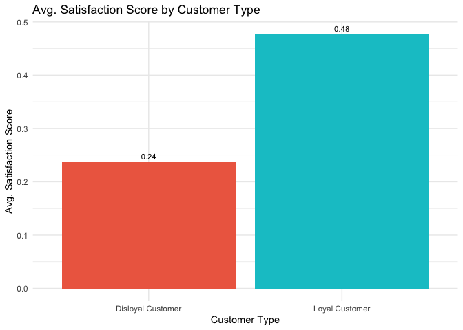

```r
ggplot(aggregate(satisfaction ~ `Customer Type`, data = train, FUN = mean),
       aes(x = factor(`Customer Type`, labels = c("Disloyal Customer", "Loyal Customer")), y = satisfaction)) +
  geom_bar(stat = "identity", aes(fill = factor(`Customer Type`))) +
  labs(title = "Avg. Satisfaction Score by Customer Type",
       x = "Customer Type",
       y = "Avg. Satisfaction Score") +
  theme_minimal() +
  scale_fill_manual(values = c("coral2", "turquoise3")) +
  geom_text(aes(label = round(satisfaction, 2)), vjust = -0.5, color = "black", size = 3) +
  theme(legend.position = "none")
```

##### For the first part of my anaylsis I wanted to delve into the different satisfaction level among key demographic groups. From this first graph above, I can see that customers identified as loyal report a much higher satisfaction score on average when compared to disloyal customers, or .48 and .24 respectively. This is understandable as loyal customers are likely to have found an airline they enjoy and will stick with, thus growing their reputation with the airline and gaining rewards through specific mile points programs.

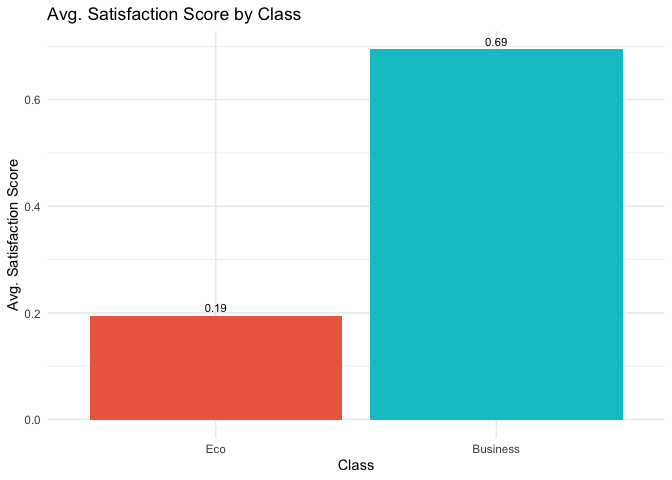

```r
ggplot(aggregate(satisfaction ~ `Class`, data = train, FUN = mean),
       aes(x = factor(`Class`, labels = c("Eco", "Business")), y = satisfaction)) +
  geom_bar(stat = "identity", aes(fill = factor(`Class`))) +
  labs(title = "Avg. Satisfaction Score by Class",
       x = "Class",
       y = "Avg. Satisfaction Score") +
  scale_fill_manual(values = c("coral2", "turquoise3")) +
  theme_minimal() +
  geom_text(aes(label = round(satisfaction, 2)), vjust = -0.5, color = "black", size = 3) +
  theme(legend.position = "none")
```

##### From this graph above, when comparing customers in economy vs business class, I can see that business class customers on average report a much higher satisfaction score, likely due to the improve flight accomedations, improved legroom, and overall improve inflight experiences. In this comparison, the busines customers reported an average score of .69, while economcy class customers only reported a score of .19.

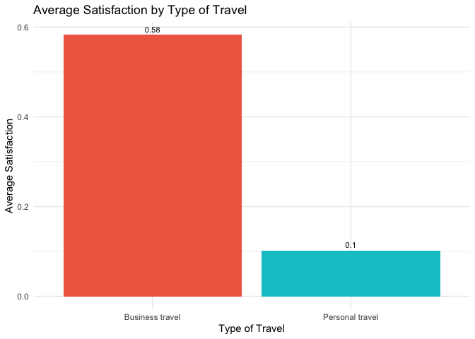

```r
ggplot(aggregate(satisfaction ~ `Type of Travel`, data = train, FUN = mean),
       aes(x = factor(`Type of Travel`, labels = c("Business travel", "Personal travel")), y = satisfaction)) +
  geom_bar(stat = "identity", aes(fill = factor(`Type of Travel`))) +
  labs(title = "Average Satisfaction by Type of Travel",
       x = "Type of Travel",
       y = "Average Satisfaction") +
  scale_fill_manual(values = c("coral2", "turquoise3")) +
  theme_minimal() +
  geom_text(aes(label = round(satisfaction, 2)), vjust = -0.5, color = "black", size = 3) +
  theme(legend.position = "none")
```

##### Next, I wanted to compare the difference in satisfaction scores between personal and business travelers. As you can see above, Business travleres report a much higher satisfaction score at .58 while personal travlers report a score of only .10. This makes sense because business travelers are often more consitent flyers, meaning they are likely to particpate in and make me of airlines rewards programs that provide them extra benefits such as preflight lounges, better seats, and cheaper flights using mile points.

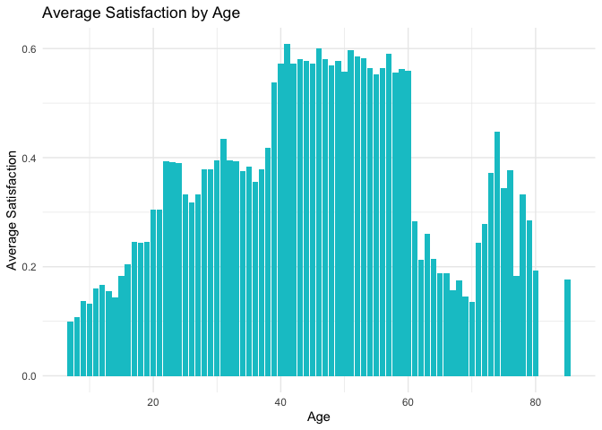

```r
ggplot(aggregate(satisfaction ~ Age, data = train, FUN = mean),
       aes(x = Age, y = satisfaction)) +
  geom_bar(stat = "identity", fill = "turquoise3") +
  labs(title = "Average Satisfaction by Age",
       x = "Age",
       y = "Average Satisfaction") +
  theme_minimal()
```

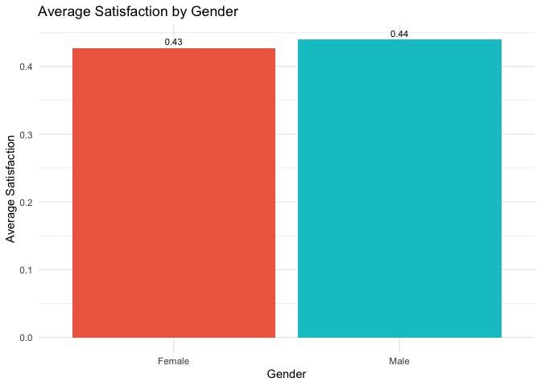

```r
ggplot(aggregate(satisfaction ~ Gender, data = train, FUN = mean),
       aes(x = factor(Gender, labels = c("Female", "Male")), y = satisfaction, fill = factor(Gender))) +
  geom_bar(stat = "identity") +
  labs(title = "Average Satisfaction by Gender",
       x = "Gender",
       y = "Average Satisfaction") +
  scale_fill_manual(values = c("coral2", "turquoise3")) +
  theme_minimal() +
  geom_text(aes(label = round(satisfaction, 2)), vjust = -0.5, color = "black", size = 3) +
  theme(legend.position = "none")
```

##### Finally, for demographics I wanted to quickly compare the difference in staisfcation scores between genders in my survey, and as you can see above, there is no real statisical difference between the with male respondents reporting a score of .44 while women reported a score fo .43.

### Logistic Regression (Demographics)

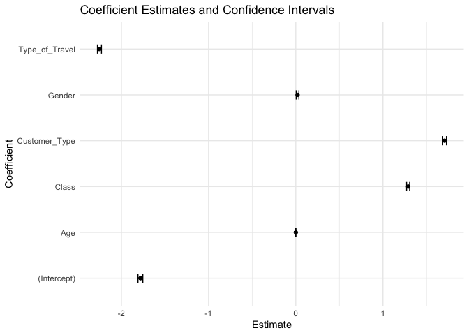

```r
names(train) <- gsub(" ", "_", names(train))

APSatmodel_logit <- glm(satisfaction ~ Age + Gender + Class + Customer_Type + Type_of_Travel,
                        data = train, family = binomial())

# summary(APSatmodel_logit)

tidy_model <- broom::tidy(APSatmodel_logit)

ggplot(tidy_model, aes(x = term, y = estimate)) +
  geom_point() +
  geom_errorbar(aes(ymin = estimate - std.error, ymax = estimate + std.error), width = 0.2) +
  theme_minimal() +
  labs(x = "Coefficient", y = "Estimate",
       title = "Coefficient Estimates and Confidence Intervals") +
  coord_flip()
```

##### This code above, generates a new linear model that aims to identify the impact of the demographic variables on the customer satisfaction. From this coefficient plot, I can see that the most impactful variable on satisfcation is “Type_of_Travel” at -2.25 (p-value less then 0.05) meaning that customers who travel for business are signifcantly more likely to report a satisfied flight, likely due to their consistent travel and likely use of rewards programs. The second most impactful varibale is “Customer_Type” at 1.706 (p-value less then 0.05) which implies that Loyal customers are significantly more likely to report a positive satisfaction over disloyal customers. Similarly to “Type_of_Travel” this makes sense as loyal customers are likely to fly often and make use of rewards programs.

### Logistic Regression (Arrivel/Departure Delays)

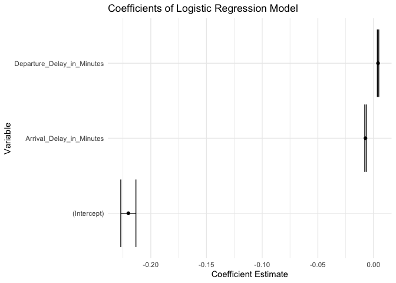

```r
logmod <- glm(satisfaction ~ `Departure_Delay_in_Minutes` + `Arrival_Delay_in_Minutes`, data = train, family = binomial)

coefficients <- summary(logmod)$coefficients

coefficients_df <- as.data.frame(coefficients)
coefficients_df$Variable <- rownames(coefficients_df)
rownames(coefficients_df) <- NULL

ggplot(data = coefficients_df, aes(y = Variable, x = Estimate)) +
  geom_point() +
  geom_errorbarh(aes(xmin = Estimate - `Std. Error`, xmax = Estimate + `Std. Error`)) +
  labs(title = "Coefficients of Logistic Regression Model",
       x = "Coefficient Estimate",
       y = "Variable") +
  theme_minimal()
```

```r
summary(logmod)
```

```
##
## Call:
## glm(formula = satisfaction ~ Departure_Delay_in_Minutes + Arrival_Delay_in_Minutes,
##     family = binomial, data = train)
##
## Coefficients:
##                              Estimate Std. Error z value Pr(>|z|)
## (Intercept)                -0.2201797  0.0067958 -32.400  < 2e-16 ***
## Departure_Delay_in_Minutes  0.0040626  0.0006599   6.157 7.43e-10 ***
## Arrival_Delay_in_Minutes   -0.0072306  0.0006531 -11.071  < 2e-16 ***
## ---
## Signif. codes:  0 '***' 0.001 '**' 0.01 '*' 0.05 '.' 0.1 ' ' 1
##
## (Dispersion parameter for binomial family taken to be 1)
##
##     Null deviance: 141768  on 103593  degrees of freedom
## Residual deviance: 141360  on 103591  degrees of freedom
##   (310 observations deleted due to missingness)
## AIC: 141366
##
## Number of Fisher Scoring iterations: 4
```

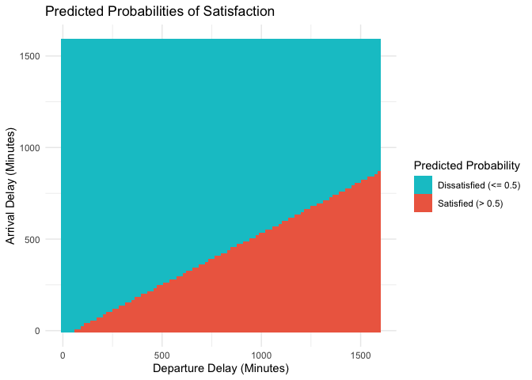

```r
newdata <- expand.grid(
  `Departure_Delay_in_Minutes` = seq(min(train$`Departure_Delay_in_Minutes`, na.rm = TRUE), max(train$`Departure_Delay_in_Minutes`, na.rm = TRUE), length.out = 100),
  `Arrival_Delay_in_Minutes` = seq(min(train$`Arrival_Delay_in_Minutes`, na.rm = TRUE), max(train$`Arrival_Delay_in_Minutes`, na.rm = TRUE), length.out = 100)
)
newdata$satisfaction <- predict(logmod, newdata, type = "response")

ggplot(data = newdata, aes(x = `Departure_Delay_in_Minutes`, y = `Arrival_Delay_in_Minutes`, fill = satisfaction > 0.5)) +
  geom_tile() +
  scale_fill_manual(values = c("turquoise3", "coral2"), name = "Predicted Probability", labels = c("Dissatisfied (<= 0.5)", "Satisfied (> 0.5)")) +
  labs(title = "Predicted Probabilities of Satisfaction",
       x = "Departure Delay (Minutes)",
       y = "Arrival Delay (Minutes)") +
  theme_minimal()
```

##### Using the same liear regression model as defined previously, the code above predict whether or not a customer will be satisfied dependent on arrival delay and departure delay. As you can see the probability for a customer being satisfied is less affected by Departure Delays than it is by arrival delays.

### Pre-Flight Factors on Satisfaction

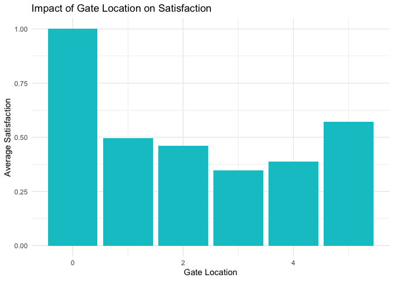

```r
gate_location_impact <- train %>% group_by(`Gate_location`) %>% summarise(Avg_Satisfaction = mean(satisfaction, na.rm = TRUE))

ggplot(gate_location_impact, aes(x = `Gate_location`, y = Avg_Satisfaction)) + geom_bar(stat = "identity", fill = "turquoise3") + theme_minimal() + labs(title = "Impact of Gate Location on Satisfaction", x = "Gate Location", y = "Average Satisfaction")
```

##### For my next analysis, I wanted to idenitfy how gate location rating, impacted the customers satisfaction level. Surpringsly to us, my analysis above shows that gate location satisfaction had little consitent impact on overall satisfaction. As you can see the lowest possible gate location ratings also recived the highest overall satisfaction score. I believe this might be the case because gate location is something that can very drastically from airport to airport, and what might be considered a good location at one airport could then lead to what is considered a bad location at the next.

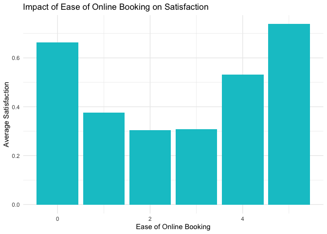

```r
online_booking_impact <- train %>% group_by(`Ease_of_Online_booking`) %>% summarise(Avg_Satisfaction = mean(as.numeric(satisfaction), na.rm = TRUE))

online_booking_impact <- train %>% group_by(`Ease_of_Online_booking`) %>% summarise(Avg_Satisfaction = mean(satisfaction, na.rm = TRUE))

ggplot(online_booking_impact, aes(x = `Ease_of_Online_booking`, y = Avg_Satisfaction)) + geom_bar(stat = "identity", fill = "turquoise3") + theme_minimal() + labs(title = "Impact of Ease of Online Booking on Satisfaction", x = "Ease of Online Booking", y = "Average Satisfaction")
```

##### Continuing my analysis, I aimed to determine the influence of the ease of online booking on customer satisfaction levels. Surprisingly, I found that both the highest and lowest ease of booking scores corresponded to the highest overall satisfaction scores. This unexpected finding suggests that factors beyond the booking experience may have a more significant impact on overall satisfaction. One plausible explanation could be that customers tend to book their flights well in advance, and any challenges they encountered during the booking process may have become less relevant by the time they completed the survey.

### Logsitc Regression Model for Predictive Testing

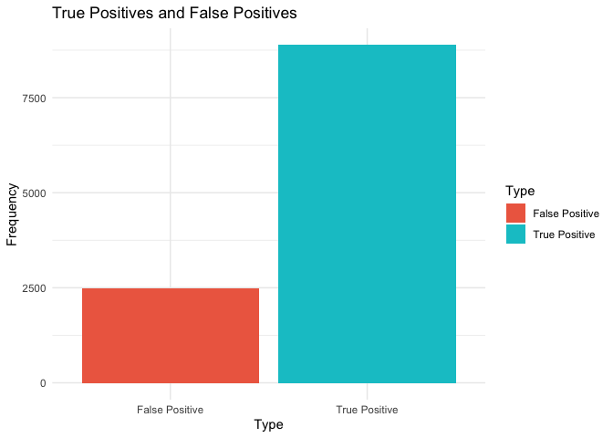

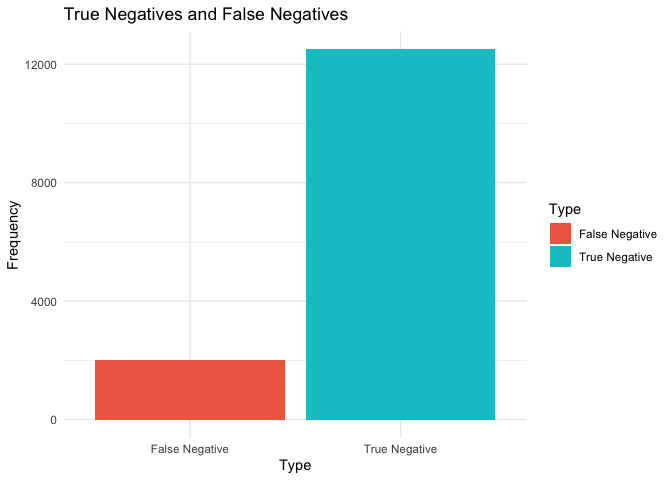

```r
colnames(test) <- gsub(" ", "_", colnames(test))

modeltrain <- glm(satisfaction ~ `Flight_Distance` + `Inflight_wifi_service` + `Departure/Arrival_time_convenient` + `Ease_of_Online_booking` + `Gate_location` + `Food_and_drink` + `Online_boarding` + `Seat_comfort` + `Inflight_entertainment` + `On-board_service` + `Leg_room_service` + `Baggage_handling` + `Checkin_service` + `Inflight_service` + `Cleanliness` + `Departure_Delay_in_Minutes` + `Arrival_Delay_in_Minutes`, data = train)

test$predicted_satisfaction <- ifelse(predict(modeltrain, newdata = test, type = "response") > 0.5, 1, 0)

conf_matrix <- table(test$predicted_satisfaction, test$satisfaction)

accuracy <- sum(diag(conf_matrix)) / sum(conf_matrix)

true_positives <- conf_matrix[2, 2]
false_positives <- conf_matrix[1, 2]
true_negatives <- conf_matrix[1, 1]
false_negatives <- conf_matrix[2, 1]

tp_fp <- data.frame(Type = c("True Positive", "False Positive"), Frequency = c(true_positives, false_positives))
tn_fn <- data.frame(Type = c("True Negative", "False Negative"), Frequency = c(true_negatives, false_negatives))

barplot_tp_fp <- ggplot(tp_fp, aes(x = Type, y = Frequency, fill = Type)) +
  geom_bar(stat = "identity") +
  labs(title = "True Positives and False Positives", x = "Type", y = "Frequency") +
  scale_fill_manual(values = c("coral2", "turquoise3")) +
  theme_minimal()

barplot_tn_fn <- ggplot(tn_fn, aes(x = Type, y = Frequency, fill = Type)) +
  geom_bar(stat = "identity") +
  labs(title = "True Negatives and False Negatives", x = "Type", y = "Frequency") +
  scale_fill_manual(values = c("coral2", "turquoise3")) +
  theme_minimal()
```

### Correlation Between In-Flight Amenities and Satisfaction

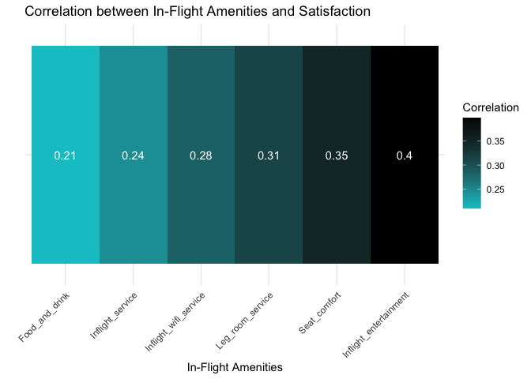

```r
amenities <- c("Inflight_wifi_service", "Food_and_drink", "Seat_comfort", "Inflight_entertainment", "Inflight_service", "Leg_room_service")
train[amenities] <- lapply(train[amenities], as.numeric)

correlation_results <- sapply(amenities, function(amenity) {
  cor(train[[amenity]], train$satisfaction)
})

correlation_df <- data.frame(Amenity = amenities, Correlation = correlation_results)

correlation_df <- correlation_df[order(abs(correlation_df$Correlation)), ]

ggplot(data = correlation_df, aes(x = reorder(Amenity, Correlation), y = "", fill = Correlation)) +
  geom_tile() +
  geom_text(aes(label = round(Correlation, 2)), color = "white") +
  scale_fill_gradient(low = "turquoise3", high = "black") +
  labs(title = "Correlation between In-Flight Amenities and Satisfaction",
       x = "In-Flight Amenities",
       y = "") +
  theme_minimal() +
  theme(axis.text.x = element_text(angle = 45, hjust = 1))
```

##### Another question I had from my dataset was wanting to better understand which inflight amenities had the greatest impact on the overall satisfaction of customers. I thought this could be really informative to airlines as they would be able to identify which aspects of their flights were most important to their customers satisfaction level, thus helping them to understand where they should take extra care in flight preparations. So in order to accomplish this I first created a correlation heat map comparing correlation between overall customer satisfaction with each of the 6 main inflight amenities, and as you can see here inflight entertainment has the strongest correlation with satisfaction, meaning that as satisfaction levels for inflight entertainment increases so does overall satisfaction. Thus telling me that inflight entertainment can really influence how enjoyable a flight is for their customers.

### K-mean Clustering

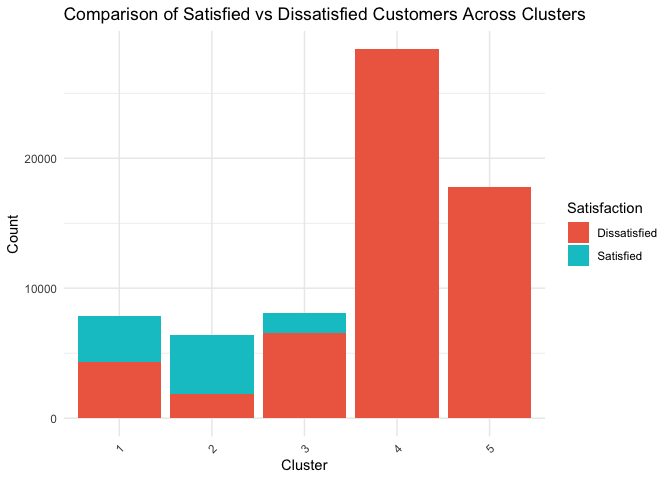

```
## # A tibble: 5 × 7
##   Cluster   Age Gender Customer_Type Type_of_Travel Class satisfaction
##     <int> <dbl>  <dbl>         <dbl>          <dbl> <dbl>        <dbl>
## 1       1  42.0  0.492         0.960        0.141   0.817        0.646
## 2       2  43.5  0.499         0.998        0.00572 0.993        0.775
## 3       3  40.3  0.500         0.899        0.222   0.684        0.554
## 4       4  39.0  0.488         0.760        0.391   0.313        0.331
## 5       5  37.1  0.493         0.742        0.403   0.312        0.326
```

```r
train_copy <- select(train, -id, -`...1`)

train_encoded <- dummy_cols(train_copy, select_columns = c("Gender", "Customer Type", "Type of Travel", "Class", "satisfaction"), remove_first_dummy = TRUE)

numerical_train_encoded <- select(train_encoded, where(is.numeric))

numerical_train_imputed <- numerical_train_encoded %>%
  mutate(across(everything(), ~ifelse(is.na(.), mean(., na.rm = TRUE), .)))

set.seed(100)
kmeans_result <- kmeans(numerical_train_imputed, centers = 5, nstart = 25, iter.max = 500)

train_copy$Cluster <- kmeans_result$cluster

cluster_summary <- train_copy %>%
  group_by(Cluster) %>%
  summarise(across(c("Age", "Gender", "Customer_Type", "Type_of_Travel", "Class", "satisfaction"), mean, na.rm = TRUE))

write_csv(train_copy, "clustered_data.csv")

numerical_train_matrix <- as.matrix(numerical_train_imputed)

satisfied_counts <- train_copy %>%
  group_by(Cluster, satisfaction) %>%
  summarise(count = n()) %>%
  filter(satisfaction == 1) %>%
  rename(Satisfied = count)

dissatisfied_counts <- train_copy %>%
  group_by(Cluster, satisfaction) %>%
  summarise(count = n()) %>%
  filter(satisfaction == 0) %>%
  rename(Dissatisfied = count)

combined_counts <- merge(satisfied_counts, dissatisfied_counts, by = "Cluster", all = TRUE)
combined_counts[is.na(combined_counts)] <- 0

ggplot(combined_counts, aes(x = as.factor(Cluster))) +
  geom_bar(aes(y = Satisfied, fill = "Satisfied"), stat = "identity") +
  geom_bar(aes(y = Dissatisfied, fill = "Dissatisfied"), stat = "identity") +
  labs(title = "Comparison of Satisfied vs Dissatisfied Customers Across Clusters",
       x = "Cluster", y = "Count", fill = "Satisfaction") +
  scale_fill_manual(values = c("Satisfied" = "turquoise3", "Dissatisfied" = "coral2")) +
  theme_minimal() +
  theme(axis.text.x = element_text(angle = 45, hjust = 1))
```

##### Finally I wanted to implement a k-means clustering in order to better segment satisfied and disastisfied customers. The K-means clustering analysis yielded five distinct customer clusters based on various demographic and satisfaction-related attributes. Each cluster exhibits different characteristics that can help airlines understand their customer base better. Cluster 1, for instance, has a relatively higher average age compared to other clusters and consists mostly of customers who predominantly travel for business purposes, indicating a segment of experienced and possibly frequent business travelers. On the other hand, Cluster 5 comprises younger individuals with a slightly lower satisfaction score, suggesting a group that may be less satisfied with their flight experiences. Understanding these clusters can assist airlines in tailoring their services and marketing strategies to better meet the needs and preferences of different customer segments. For instance, Cluster 2 represents highly satisfied customers across various demographics, presenting an opportunity for airlines to identify and replicate factors contributing to their satisfaction to enhance overall customer experience. Additionally, by segmenting customers into clusters, airlines can optimize resource allocation and targeted marketing efforts, focusing resources where they are most needed and identifying areas for improvement to increase overall customer satisfaction and loyalty.

## Summary of Marketing Insights

##### The marketing research analysis conducted on the vast dataset of airline customer experience surveys, encompassing over 100,000 respondents, has revealed significant insights into factors influencing overall satisfaction levels. Through rigorous data analysis, correlations between various amenities and overall satisfaction have been uncovered. For instance, amenities like inflight entertainment and seat comfort exhibit robust positive correlations with overall satisfaction, emphasizing the pivotal role of onboard services in shaping passengers’ perceptions of their travel experiences. Surprisingly, gate location satisfaction demonstrated little consistent impact on overall satisfaction, suggesting potential misconceptions in customer priorities.

##### Furthermore, the analysis delved into the impact of ease of online booking on overall satisfaction levels. Contrary to initial expectations, both the highest and lowest ease of booking scores corresponded to the highest overall satisfaction scores. This unexpected finding underscores the nuanced nature of customer satisfaction, suggesting that factors beyond the booking process may significantly influence passengers’ overall satisfaction levels. Additionally, the logistic regression model, achieving an 82% accuracy rate in predicting customer satisfaction, offers airlines a powerful tool to proactively address customer concerns and tailor services to enhance overall satisfaction levels.

##### In addition to these findings, the k-means clustering analysis yielded valuable insights into customer segmentation. The clustering identified five distinct customer clusters based on demographic and satisfaction-related attributes. For example, Cluster 1 consists predominantly of experienced business travelers with relatively high satisfaction levels, while Cluster 5 comprises younger individuals with slightly lower satisfaction scores. Understanding these clusters enables airlines to tailor services and marketing strategies to meet the unique needs and preferences of different customer segments. Moreover, the logistic regression coefficients for demographic variables provide actionable insights into the factors influencing customer satisfaction. For instance, “Type_of_Travel” emerged as the most impactful variable, highlighting the significant influence of business travel on overall satisfaction levels. By leveraging these insights, airlines can optimize resource allocation, target marketing efforts effectively, and ultimately enhance overall customer satisfaction, loyalty, and business performance in the competitive airline industry.

#### Thank You for Your Time :)